# HW1_ DV_SYYarovoy

# 8. Проведите линию тренда для предыдущего графика.

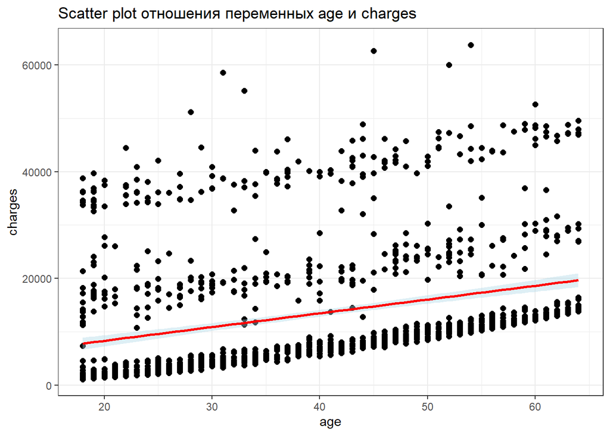

```r
scat2 <- scat +
  geom_smooth(method=lm,
              color="red", fullrange = T,
              fill="lightblue",
              se=TRUE) +
  theme_bw()

scat2
```

# 9. Сделайте разбивку предыдущего графика по колонке smokers (у вас должно получится две линии тренда для курящих и нет).

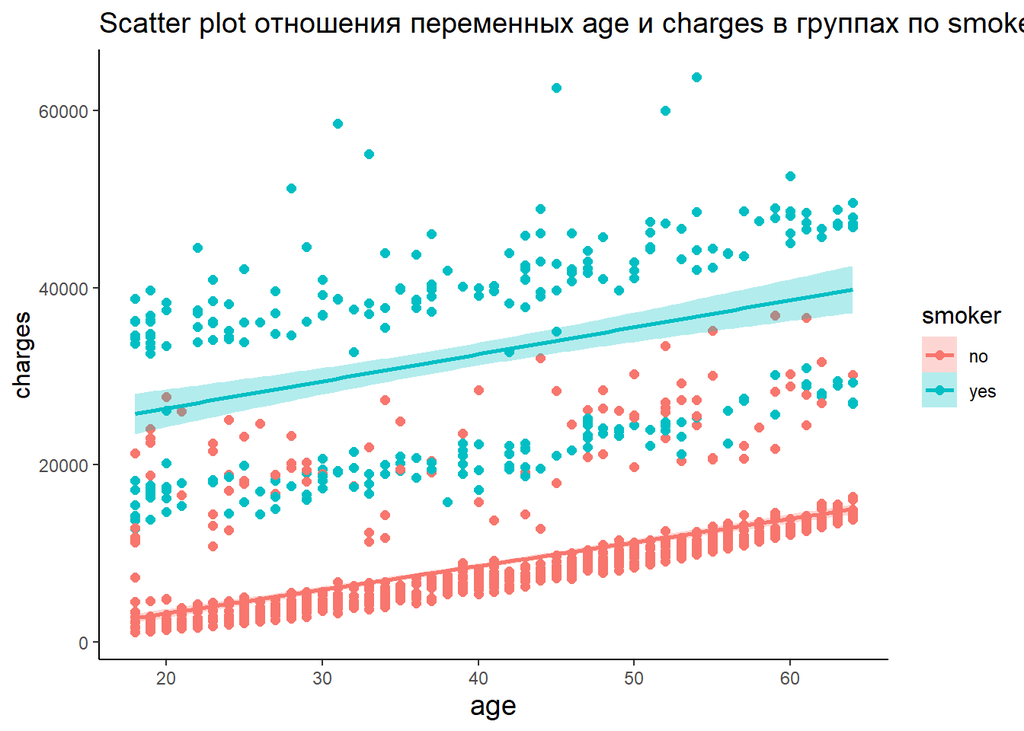

```r
scat3 <- insurance %>%
  ggplot(aes(x=age, y=charges, color = smoker, fill = smoker, group = smoker)) +
  geom_point(size=2) +
  theme_classic() +
  ggtitle('Scatter plot отношения переменных age и charges в группах по smoker') +
  labs(y = 'charges', x = 'age') +
  geom_smooth(method=lm,
              fullrange = T,
              alpha = 0.3,
              se=T) +
  theme(
    title = element_text(size = 12),
    axis.title.x = element_text(size=14)
    )

scat3
```

# 10. Сделайте график из заданий 7-9, но вместо переменной age используйте переменную bmi.

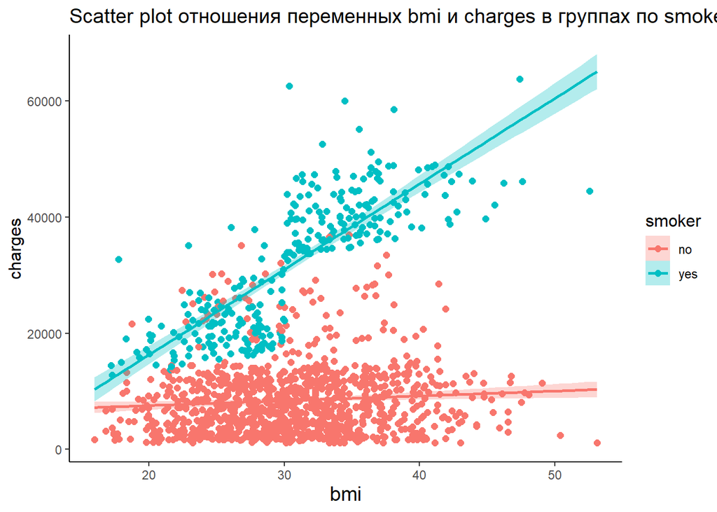

```r
scat4 <- insurance %>%
  ggplot(aes(x=bmi, y=charges, color = smoker, fill = smoker, group = smoker)) +
  geom_point(size=2) +
  theme_classic() +
  ggtitle('Scatter plot отношения переменных bmi и charges в группах по smoker') +
  labs(y = 'charges', x = 'bmi') +
  geom_smooth(method=lm,
              fullrange = T,
              alpha = 0.3,
              se=T) +
  theme(
    title = element_text(size = 12),
    axis.title.x = element_text(size=14)
    )

scat4
```

# 11. Самостоятельно задайте вопрос No1 к данным (вопрос должен быть про какую-то подвыборку данных). Ответьте на него построив график на подвыборке данных. График должен содержать все основные элементы оформления (название, подписи осей, тему и проч.). Аргументируйте выбор типа графика.

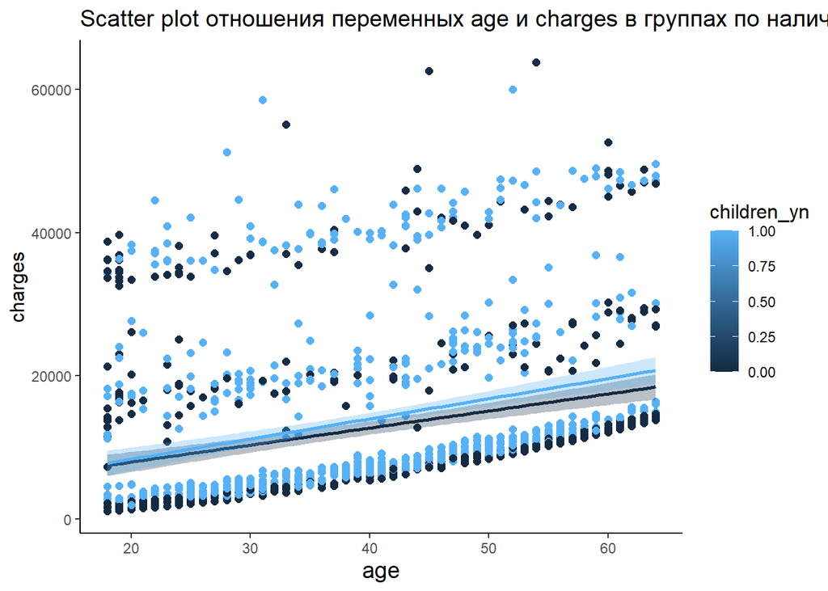

```r
#Как зависит страховка от возраста при наличии/отсутствии детей

scat5 <- insurance %>%
  mutate(children_yn = ifelse(children == 0, 0, 1)) %>%
  ggplot(aes(x=age, y=charges, color = children_yn, fill = children_yn, group = children_yn)) +
  geom_point(size=2) +
  theme_classic() +
  ggtitle('Scatter plot отношения переменных age и charges в группах по наличию children') +
  labs(y = 'charges', x = 'age') +
  geom_smooth(method=lm,
              fullrange = T,
              alpha = 0.3,
              se=T) +
  theme(
    title = element_text(size = 12),
    axis.title.x = element_text(size=14)
    )

scat5
```

```r
#Можно предположить, что с увеличением возраста страховка должна быть более дорогой (подтверждается предыдущими графиками), однако эта разница может увеличиваться при наличии детей ("отрицательно" влияют на здоровье родителей, поскольку могут повышать уровень стресса). scatter plot с линейной моделью - для анализа двух количественных переменных, сгруппированных по качественной переменной. Влияние наличия детей на стоимость страховки четко не прослеживается.
```